# PARTY AND DATE HUBS IN PROTEIN-PROTEIN INTERACTION NETWORKS

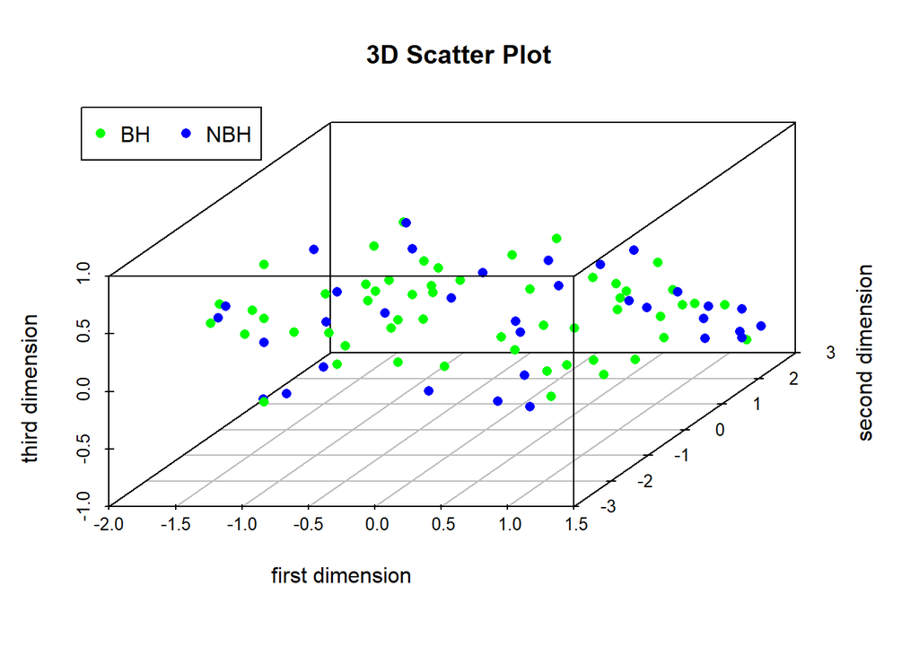

```r
# after matching together allpersonsBH and allpersonsNBH
scatterplot3d(x=U_ALL[,1],y=U_ALL[,2],z=U_ALL[,3],
              main="3D Scatter Plot",
              xlab = "first dimension",
              ylab = "second dimension",
              zlab = " third dimension", pch = 16, color=colors)
legend("topleft", legend = c("BH", "NBH"),col = c("green", "blue"),horiz=TRUE, xpd = TRUE,pch = 16,angle=55)
```

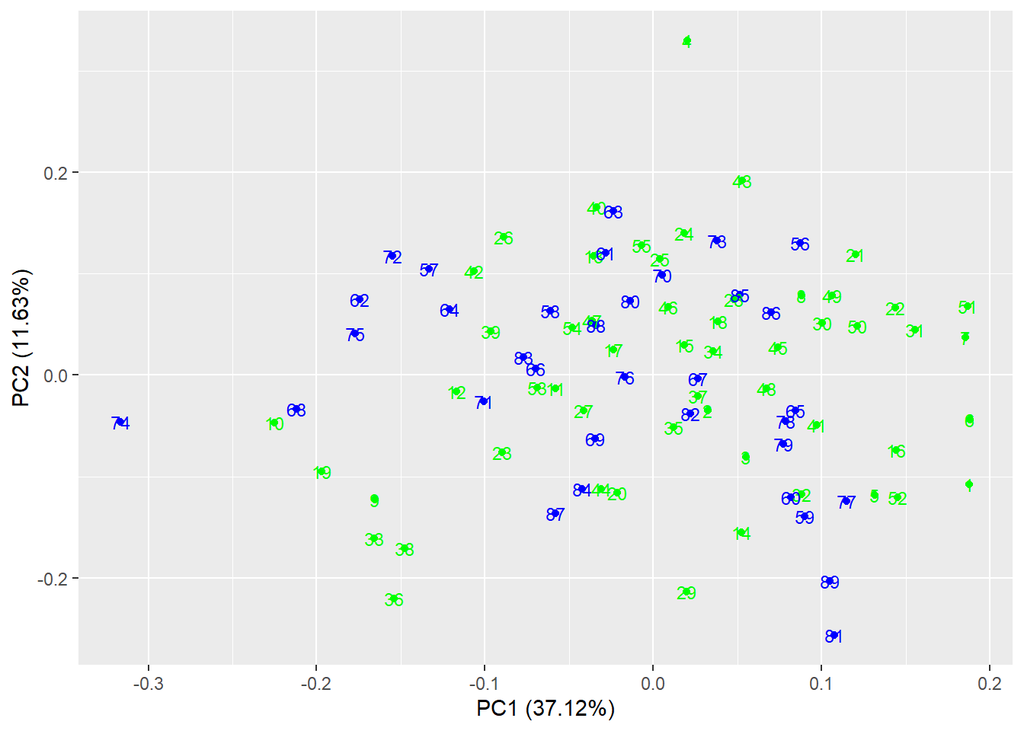

```r
# trying to explore some particular structure with the PCA
pca_res <- prcomp(ALLpersons_T, scale. = F)
autoplot(pca_res, colour = colors, label = TRUE, label.size = 3)
```

Giving an interpretation from a graphical point of view is not easy. We can start by saying that the new points in both the 3D representation and the scatterplot are the BH and NBH. There seems to be a rather similar trend and we do not have a clear cluster for these populations.Looking at the scatterplot, we can observe the same trend between the BH and NBH populations, as there are no areas in which they are more concentrated. Even through the PCA technique we do not see a clear separation between populations resulting in the formation of clusters.

## **Conclusion**

This project aims to integrate the 4 categories **(BH,NBH,BNH,NBNH)** above with the idea of **party** and **data hubs** using an interactome for E. coli and a gene expression compendium. The network is used to define the above groups based on two topological properties (**degree**, to define hubness and **betweenness centrality**, to define bottleneckness). Through a first analysis based on Pearson correlation we hypothesise that BHs have lower values of PCC and consequently this would correspond to the presence of data hubs. In NBH, however, a completely different situation occurs. In both cases we cannot exclude the possible presence of date and party hubs in both BH and NBH. There seems to be no particular difference between the first and the second filtered dataset. Unfortunately we are not able to identify any particular inner structures from a graphical point of view.

## **References**

1.Han JDJ, Bertin N, Hao T, Goldberg DS, Berriz GF, et al. (2004) Evidence for dynamically organized modularity in the yeast protein-protein interaction network. Nature 430: 88–93.

2.Yu H, Kim PM, Sprecher E, Trifonov V, Gerstein M (2007) The importance of bottlenecks in protein networks: Correlation with gene essentiality and expression dynamics. PLoS Comput Biol 3: e59 https://doi.org/10.1371/journal.pcbi.0030059

3.Agarwal Sumeet, Porter Mason A., Deane Charlotte M. 2010. “Revisiting Date and Party Hubs: Novel Approaches to Role Assignment in Protein Interaction Networks.” PLOS Computational Biology 6 (June): 1–12. https://doi.org/10.1371/journal.pcbi.1000817

4.Bozhilova, L.V., Whitmore, A.V., Wray, J. et al. Measuring rank robustness in scored protein interaction networks. BMC Bioinformatics 20, 446 (2019). https://doi.org/10.1186/s12859-019-3036-6

5.Mirzarezaee, M., Araabi, B.N. & Sadeghi, M. Features analysis for identification of date and party hubs in protein interaction network of Saccharomyces Cerevisiae. BMC Syst Biol 4, 172 (2010). https://doi.org/10.1186/1752-0509-4-172

6.Batada NN, Reguly T, Breitkreutz A, Boucher L, Breitkreutz BJ, Hurst LD, Tyers M: Stratus not altocumulus: A new view of the yeast protein interaction network. PLoS Biol. 2006, 4: e317- 10.1371/journal.pbio.0040317

7.Jin G, Zhang S, Zhang XS, Chen L: Hubs with network motifs organize modularity dynamically in the protein-protein interaction network of yeast. PLoS ONE. 2007, 2: e1207- 10.1371/journal.pone.0001207

8.Szklarczyk D, Gable AL, Nastou KC, Lyon D, Kirsch R, Pyysalo S, Doncheva NT, Legeay M, Fang T, Bork P‡, Jensen LJ‡, von Mering C‡. The STRING database in 2021: customizable protein–protein networks, and functional characterization of user-uploaded gene/measurement sets . Nucleic Acids Res. 2021 Jan 8;49(D1):D605-12.